# Week 2: Interpretable Machine Learning - A Guide for Making Black Box Models Explainable (Christoph Molnar)

Big Data and Machine Learning for Applied Economics - | Econ 4676

Eduard-Martínez y Lucas II

Universidad de los Andes

## **1. Linear regression**

A linear regression model predicts the target as a weighted sum of the feature inputs. The linearity of the learned relationship makes the interpretation easy. Linear regression models have long been used by statisticians, computer scientists and other people who tackle quantitative problems.

Linear models can be used to model the dependence of a regression target y on some features x. The learned relationships are linear and can be written for a single instance i as follows:

$$y=\beta_{0}+\beta_{1}x_{1}+\ldots+\beta_{p}x_{p}+\epsilon$$

The predicted outcome of an instance is a weighted sum of its p features. The betas ($\beta_{j}$) represent the learned feature weights or coefficients. The first weight in the sum ($\beta_0$) is called the intercept and is not multiplied with a feature. The epsilon ($\epsilon$) is the error we still make, i.e. the difference between the prediction and the actual outcome. These errors are assumed to follow a Gaussian distribution, which means that we make errors in both negative and positive directions and make many small errors and few large errors.

Various methods can be used to estimate the optimal weight. The ordinary least squares method is usually used to find the weights that minimize the squared differences between the actual and the estimated outcomes:

$$\hat{\boldsymbol{\beta}}=\arg\!\min_{\beta_0,\ldots,\beta_p}\sum_{i=1}^n\left(y^{(i)}-\left(\beta_0+\sum_{j=1}^p\beta_jx^{(i)}_{j}\right)\right)^{2}$$

We will not discuss in detail how the optimal weights can be found, but if you are interested, you can read chapter 3.2 of the book “The Elements of Statistical Learning” (Friedman, Hastie and Tibshirani 2009) or one of the other online resources on linear regression models.

The biggest advantage of linear regression models is linearity: It makes the estimation procedure simple and, most importantly, these linear equations have an easy to understand interpretation on a modular level (i.e. the weights). This is one of the main reasons why the linear model and all similar models are so widespread in academic fields such as medicine, sociology, psychology, and many other quantitative research fields. For example, in the medical field, it is not only important to predict the clinical outcome of a patient, but also to quantify the influence of the drug and at the same time take sex, age, and other features into account in an interpretable way.

Estimated weights come with confidence intervals. A confidence interval is a range for the weight estimate that covers the “true” weight with a certain confidence. For example, a 95% confidence interval for a weight of 2 could range from 1 to 3. The interpretation of this interval would be: If we repeated the estimation 100 times with newly sampled data, the confidence interval would include the true weight in 95 out of 100 cases, given that the linear regression model is the correct model for the data.

Whether the model is the “correct” model depends on whether the relationships in the data meet certain assumptions, which are linearity, homoscedasticity, independence and absence of multicollinearity.

**Linearity**  
The linear regression model forces the prediction to be a linear combination of features, which is both its greatest strength and its greatest limitation. Linearity leads to interpretable models. Linear effects are easy to quantify and describe. They are additive, so it is easy to separate the effects. If you suspect feature interactions or a nonlinear association of a feature with the target value, you can add interaction terms or use regression splines.

**Homoscedasticity** (constant variance)  
The variance of the error terms is assumed to be constant over the entire feature space. Suppose you want to predict the value of a house given the living area in square meters. You estimate a linear model that assumes that, regardless of the size of the house, the error around the predicted response has the same variance. This assumption is often violated in reality. In the house example, it is plausible that the variance of error terms around the predicted price is higher for larger houses, since prices are higher and there is more room for price fluctuations. Suppose the average error (difference between predicted and actual price) in your linear regression model is 50,000 Euros. If you assume homoscedasticity, you assume that the average error of 50,000 is the same for houses that cost 1 million and for houses that cost only 40,000. This is unreasonable because it would mean that we can expect negative house prices.

**Independence**  
It is assumed that each instance is independent of any other instance. If you perform repeated measurements, such as multiple blood tests per patient, the data points are not independent. For dependent data you need special linear regression models, such as mixed effect models or GEEs. If you use the “normal” linear regression model, you might draw wrong conclusions from the model.

**Absence of multicollinearity**  
You do not want strongly correlated features, because this messes up the estimation of the weights. In a situation where two features are strongly correlated, it becomes problematic to estimate the weights because the feature effects are additive and it becomes indeterminable to which of the correlated features to attribute the effects.

## **2. Interpretation**

The interpretation of a weight in the linear regression model depends on the type of the corresponding feature.

- Numerical feature: Increasing the numerical feature by one unit changes the estimated outcome by its weight. An example of a numerical feature is the size of a house.
- Binary feature: A feature that takes one of two possible values for each instance. An example is the feature “House comes with a garden”. One of the values counts as the reference category (in some programming languages encoded with 0), such as “No garden”. Changing the feature from the reference category to the other category changes the estimated outcome by the feature’s weight.
- Categorical feature with multiple categories: A feature with a fixed number of possible values. An example is the feature “floor type”, with possible categories “carpet”, “laminate” and “parquet”. A solution to deal with many categories is the one-hot-encoding, meaning that each category has its own binary column. For a categorical feature with L categories, you only need L-1 columns, because the L-th column would have redundant information (e.g. when columns 1 to L-1 all have value 0 for one instance, we know that the categorical feature of this instance takes on category L). The interpretation for each category is then the same as the interpretation for binary features. Some languages, such as R, allow you to encode categorical features in various ways, as described later in this chapter.
- Intercept $\beta_0$: The intercept is the feature weight for the “constant feature”, which is always 1 for all instances. Most software packages automatically add this “1”-feature to estimate the intercept. The interpretation is: For an instance with all numerical feature values at zero and the categorical feature values at the reference categories, the model prediction is the intercept weight. The interpretation of the intercept is usually not relevant because instances with all features values at zero often make no sense. The interpretation is only meaningful when the features have been standardised (mean of zero, standard deviation of one). Then the intercept reflects the predicted outcome of an instance where all features are at their mean value.

The interpretation of the features in the linear regression model can be automated by using following text templates.

**Interpretation of a Numerical Feature**

An increase of feature $x_{k}$ by one unit increases the prediction for y by $\beta_k$ units when all other feature values remain fixed.

**Interpretation of a Categorical Feature**

Changing feature $x_{k}$ from the reference category to the other category increases the prediction for y by $\beta_{k}$ when all other features remain fixed.

## **3. The R-squared measurement**

Another important measurement for interpreting linear models is the R-squared measurement. R-squared tells you how much of the total variance of your target outcome is explained by the model. The higher R-squared, the better your model explains the data. The formula for calculating R-squared is:

$$R^2=1-SSE/SST$$

SSE is the squared sum of the error terms:

$$SSE=\sum_{i=1}^n(y^{(i)}-\hat{y}^{(i)})^2$$

SST is the squared sum of the data variance:

$$SST=\sum_{i=1}^n(y^{(i)}-\bar{y})^2$$

The SSE tells you how much variance remains after fitting the linear model, which is measured by the squared differences between the predicted and actual target values. SST is the total variance of the target outcome. R-squared tells you how much of your variance can be explained by the linear model. R-squared usually ranges between 0 for models where the model does not explain the data at all and 1 for models that explain all of the variance in your data. It is also possible for R-squared to take on a negative value without violating any mathematical rules. This happens when SSE is greater than SST which means that a model does not capture the trend of the data and fits to the data worse than using the mean of the target as the prediction.

There is a catch, because R-squared increases with the number of features in the model, even if they do not contain any information about the target value at all. Therefore, it is better to use the adjusted R-squared, which accounts for the number of features used in the model. Its calculation is:

$$\bar{R}^2=1-(1-R^2)\frac{n-1}{n-p-1}$$

where p is the number of features and n the number of instances.

It is not meaningful to interpret a model with very low (adjusted) R-squared, because such a model basically does not explain much of the variance. Any interpretation of the weights would not be meaningful.

**Feature Importance**

The importance of a feature in a linear regression model can be measured by the absolute value of its t-statistic. The t-statistic is the estimated weight scaled with its standard error.

$$t_{\hat{\beta}_j}=\frac{|\hat{\beta}_j-0|}{SE(\hat{\beta}_j)}$$

Let us examine what this formula tells us: The importance of a feature increases with increasing weight. This makes sense. The more variance the estimated weight has (= the less certain we are about the correct value), the less important the feature is. This also makes sense.

## **4. Example: predict the number of rented bikes**

In this example, we use the linear regression model to predict the number of rented bikes on a particular day, given weather and calendar information. Here is the list of features of the dataset:

- **season:** season (1:winter, 2:spring, 3:summer, 4:fall).
- **yr:** The year, either 2011 or 2012.
- **mnth:** month ( 1 to 12).
- **holiday:** Indicator whether the day was a holiday or not.
- **weekday:** day of the week.
- **workingday:** if day is neither weekend nor holiday is 1, otherwise is 0.
- **weathersit:**
  - 1: Clear, Few clouds, Partly cloudy, Partly cloudy
  - 2: Mist + Cloudy, Mist + Broken clouds, Mist + Few clouds, Mist
  - 3: Light Snow, Light Rain + Thunderstorm + Scattered clouds, Light Rain + Scattered clouds
  - 4: Heavy Rain + Ice Pallets + Thunderstorm + Mist, Snow + Fog
- **temp:** Temperature in Celsius.
- **hum:** Normalized humidity.
- **windspeed:** Normalized wind speed.
- **cnt:** count of total rental bikes including both casual and registered. The count is used as the target in the regression task.
- **days_since_2011:** Number of days since the 01-01-2011 (the first day in the dataset). This feature was introduced to take account of the trend over time.

For the interpretation, we examine the estimated regression weights. The features consist of numerical and categorical features. For each feature, the table shows the estimated weight, the standard error of the estimate (SE), and the absolute value of the t-statistic (|t|).

```r
rm(list = ls())

# Load relevant packages
require(pacman)
p_load(tidyverse,knitr,kableExtra,here,jtools,ggstance,broom,broom.mixed,skimr)

# Set working directory
path <- here()
setwd(path)

# Import dataset
load("bike.RData")
bike.features.of.interest = c('season','holiday', 'workingday', 'weathersit', 'temp', 'hum', 'windspeed', 'days_since_2011')
X = bike[bike.features.of.interest]
y = bike[,'cnt']
dat = cbind(X, y)

# Before run the linear model, check all the variables classes
skim(dat)
```

Data summary

| Name | dat |
| --- | --- |
| Number of rows | 731 |
| Number of columns | 9 |
| _______________________ |  |
| Column type frequency: |  |
| factor | 4 |
| numeric | 5 |
| ________________________ |  |
| Group variables | None |

**Variable type: factor**

| skim_variable | n_missing | complete_rate | ordered | n_unique | top_counts |
| --- | --- | --- | --- | --- | --- |
| season | 0 | 1 | FALSE | 4 | SUM: 188, SPR: 184, WIN: 181, FAL: 178 |
| holiday | 0 | 1 | FALSE | 2 | NO : 710, HOL: 21 |
| workingday | 0 | 1 | FALSE | 2 | WOR: 500, NO : 231 |
| weathersit | 0 | 1 | FALSE | 3 | GOO: 463, MIS: 247, RAI: 21 |

**Variable type: numeric**

| skim_variable | n_missing | complete_rate | mean | sd | p0 | p25 | p50 | p75 | p100 | hist |
| --- | --- | --- | --- | --- | --- | --- | --- | --- | --- | --- |
| temp | 0 | 1 | 15.28 | 8.60 | -5.22 | 7.84 | 15.42 | 22.80 | 32.50 | ▂▇▇▇▅ |
| hum | 0 | 1 | 62.79 | 14.24 | 0.00 | 52.00 | 62.67 | 73.02 | 97.25 | ▁▁▆▇▂ |
| windspeed | 0 | 1 | 12.76 | 5.19 | 1.50 | 9.04 | 12.13 | 15.63 | 34.00 | ▃▇▅▁▁ |
| days_since_2011 | 0 | 1 | 365.00 | 211.17 | 0.00 | 182.50 | 365.00 | 547.50 | 730.00 | ▇▇▇▇▇ |
| y | 0 | 1 | 4504.35 | 1937.21 | 22.00 | 3152.00 | 4548.00 | 5956.00 | 8714.00 | ▂▅▇▅▃ |

```r
mod = lm(y ~ ., data = dat, x = TRUE)
lm_summary = summary(mod)$coefficients

lm_summary_print = lm_summary
lm_summary_print[,'t value'] = abs(lm_summary_print[,'t value'])

pretty_rownames = function(rnames){
  rnames = gsub('^`', '', rnames)
  rnames = gsub('`$', '', rnames)
  rnames = gsub('`', ':', rnames)
  rnames
}

kable(lm_summary_print[,c('Estimate', 'Std. Error', 't value')], digits = 1, col.names = c('Weight', 'SE', "|t|"), booktabs = TRUE, center = TRUE) %>% kable_styling(position = "center")
```

|  | Weight | SE | \|t\| |
| --- | --- | --- | --- |
| (Intercept) | 2399.4 | 238.3 | 10.1 |
| seasonSPRING | 899.3 | 122.3 | 7.4 |
| seasonSUMMER | 138.2 | 161.7 | 0.9 |
| seasonFALL | 425.6 | 110.8 | 3.8 |
| holidayHOLIDAY | -686.1 | 203.3 | 3.4 |
| workingdayWORKING DAY | 124.9 | 73.3 | 1.7 |
| weathersitMISTY | -379.4 | 87.6 | 4.3 |
| weathersitRAIN/SNOW/STORM | -1901.5 | 223.6 | 8.5 |
| temp | 110.7 | 7.0 | 15.7 |
| hum | -17.4 | 3.2 | 5.5 |
| windspeed | -42.5 | 6.9 | 6.2 |
| days_since_2011 | 4.9 | 0.2 | 28.5 |

Interpretation of a numerical feature (temperature): An increase of the temperature by 1 degree Celsius increases the predicted number of bicycles by 110.7, when all other features remain fixed.

Interpretation of a categorical feature (“weathersit”): The estimated number of bicycles is -1901.5 lower when it is raining, snowing or stormy, compared to good weather – again assuming that all other features do not change. When the weather is misty, the predicted number of bicycles is -379.4 lower compared to good weather, given all other features remain the same.

All the interpretations always come with the footnote that “all other features remain the same”. This is because of the nature of linear regression models. The predicted target is a linear combination of the weighted features. The estimated linear equation is a hyperplane in the feature/target space (a simple line in the case of a single feature). The weights specify the slope (gradient) of the hyperplane in each direction. The good side is that the additivity isolates the interpretation of an individual feature effect from all other features. That is possible because all the feature effects (= weight times feature value) in the equation are combined with a plus. On the bad side of things, the interpretation ignores the joint distribution of the features. Increasing one feature, but not changing another, can lead to unrealistic or at least unlikely data points. For example increasing the number of rooms might be unrealistic without also increasing the size of a house.

```r
# Other tools of visualization of the results
# https://cran.r-project.org/web/packages/jtools/vignettes/summ.html
# R base output
summary(mod)
```

```
##
## Call:
## lm(formula = y ~ ., data = dat, x = TRUE)
##
## Residuals:
##     Min      1Q  Median      3Q     Max
## -3509.6  -397.9    78.7   534.1  3482.4
##
## Coefficients:
##                             Estimate Std. Error t value Pr(>|t|)
## (Intercept)                2399.4422   238.3066  10.069  < 2e-16 ***
## seasonSPRING                899.3182   122.2833   7.354 5.24e-13 ***
## seasonSUMMER                138.2154   161.7037   0.855 0.392977
## seasonFALL                  425.6029   110.8199   3.840 0.000134 ***
## holidayHOLIDAY             -686.1154   203.3015  -3.375 0.000778 ***
## workingdayWORKING DAY       124.9209    73.2666   1.705 0.088623 .
## weathersitMISTY            -379.3985    87.5532  -4.333 1.68e-05 ***
## weathersitRAIN/SNOW/STORM -1901.5399   223.6400  -8.503  < 2e-16 ***
## temp                        110.7096     7.0433  15.718  < 2e-16 ***
## hum                         -17.3772     3.1694  -5.483 5.80e-08 ***
## windspeed                   -42.5135     6.8917  -6.169 1.15e-09 ***
## days_since_2011               4.9264     0.1728  28.507  < 2e-16 ***
## ---
## Signif. codes:  0 '***' 0.001 '**' 0.01 '*' 0.05 '.' 0.1 ' ' 1
##
## Residual standard error: 886.9 on 719 degrees of freedom
## Multiple R-squared:  0.7936, Adjusted R-squared:  0.7904
## F-statistic: 251.2 on 11 and 719 DF,  p-value: < 2.2e-16
```

```r
# Output as a dataframe
tidy(mod)
```

```
## # A tibble: 12 × 5
##    term                      estimate std.error statistic   p.value
##    <chr>                        <dbl>     <dbl>     <dbl>     <dbl>
##  1 (Intercept)                2399.     238.       10.1   2.13e- 22
##  2 seasonSPRING                899.     122.        7.35  5.24e- 13
##  3 seasonSUMMER                138.     162.        0.855 3.93e-  1
##  4 seasonFALL                  426.     111.        3.84  1.34e-  4
##  5 holidayHOLIDAY             -686.     203.       -3.37  7.78e-  4
##  6 workingdayWORKING DAY       125.      73.3       1.71  8.86e-  2
##  7 weathersitMISTY            -379.      87.6      -4.33  1.68e-  5
##  8 weathersitRAIN/SNOW/STORM -1902.     224.       -8.50  1.07e- 16
##  9 temp                        111.       7.04     15.7   4.48e- 48
## 10 hum                         -17.4      3.17     -5.48  5.80e-  8
## 11 windspeed                   -42.5      6.89     -6.17  1.15e-  9
## 12 days_since_2011               4.93     0.173    28.5   3.48e-120
```

```r
# jtools output
summ(mod)
```

| Observations | 731 |
| --- | --- |
| Dependent variable | y |
| Type | OLS linear regression |

| F(11,719) | 251.24 |
| --- | --- |
| R² | 0.79 |
| Adj. R² | 0.79 |

|  | Est. | S.E. | t val. | p |
| --- | --- | --- | --- | --- |
| (Intercept) | 2399.44 | 238.31 | 10.07 | 0.00 |
| seasonSPRING | 899.32 | 122.28 | 7.35 | 0.00 |
| seasonSUMMER | 138.22 | 161.70 | 0.85 | 0.39 |
| seasonFALL | 425.60 | 110.82 | 3.84 | 0.00 |
| holidayHOLIDAY | -686.12 | 203.30 | -3.37 | 0.00 |
| workingdayWORKING DAY | 124.92 | 73.27 | 1.71 | 0.09 |
| weathersitMISTY | -379.40 | 87.55 | -4.33 | 0.00 |
| weathersitRAIN/SNOW/STORM | -1901.54 | 223.64 | -8.50 | 0.00 |
| temp | 110.71 | 7.04 | 15.72 | 0.00 |
| hum | -17.38 | 3.17 | -5.48 | 0.00 |
| windspeed | -42.51 | 6.89 | -6.17 | 0.00 |
| days_since_2011 | 4.93 | 0.17 | 28.51 | 0.00 |

Standard errors: OLS

```r
# Report robust standard errors
summ(mod, robust = "HC1")
```

| Observations | 731 |
| --- | --- |
| Dependent variable | y |
| Type | OLS linear regression |

| F(11,719) | 251.24 |
| --- | --- |
| R² | 0.79 |
| Adj. R² | 0.79 |

|  | Est. | S.E. | t val. | p |
| --- | --- | --- | --- | --- |
| (Intercept) | 2399.44 | 232.39 | 10.32 | 0.00 |
| seasonSPRING | 899.32 | 124.63 | 7.22 | 0.00 |
| seasonSUMMER | 138.22 | 173.09 | 0.80 | 0.42 |
| seasonFALL | 425.60 | 128.44 | 3.31 | 0.00 |
| holidayHOLIDAY | -686.12 | 285.95 | -2.40 | 0.02 |
| workingdayWORKING DAY | 124.92 | 81.13 | 1.54 | 0.12 |
| weathersitMISTY | -379.40 | 79.39 | -4.78 | 0.00 |
| weathersitRAIN/SNOW/STORM | -1901.54 | 264.59 | -7.19 | 0.00 |
| temp | 110.71 | 7.83 | 14.14 | 0.00 |
| hum | -17.38 | 2.95 | -5.89 | 0.00 |
| windspeed | -42.51 | 7.61 | -5.59 | 0.00 |
| days_since_2011 | 4.93 | 0.22 | 22.70 | 0.00 |

Standard errors: Robust, type = HC1

```r
# Standardized/scaled coefficients
summ(mod, scale = TRUE)
```

| Observations | 731 |
| --- | --- |
| Dependent variable | y |
| Type | OLS linear regression |

| F(11,719) | 251.24 |
| --- | --- |
| R² | 0.79 |
| Adj. R² | 0.79 |

|  | Est. | S.E. | t val. | p |
| --- | --- | --- | --- | --- |
| (Intercept) | 4255.89 | 110.90 | 38.38 | 0.00 |
| seasonSPRING | 899.32 | 122.28 | 7.35 | 0.00 |
| seasonSUMMER | 138.22 | 161.70 | 0.85 | 0.39 |
| seasonFALL | 425.60 | 110.82 | 3.84 | 0.00 |
| holidayHOLIDAY | -686.12 | 203.30 | -3.37 | 0.00 |
| workingdayWORKING DAY | 124.92 | 73.27 | 1.71 | 0.09 |
| weathersitMISTY | -379.40 | 87.55 | -4.33 | 0.00 |
| weathersitRAIN/SNOW/STORM | -1901.54 | 223.64 | -8.50 | 0.00 |
| temp | 952.48 | 60.60 | 15.72 | 0.00 |
| hum | -247.50 | 45.14 | -5.48 | 0.00 |
| windspeed | -220.75 | 35.78 | -6.17 | 0.00 |
| days_since_2011 | 1040.29 | 36.49 | 28.51 | 0.00 |

Standard errors: OLS; Continuous predictors are mean-centered and scaled by 1 s.d.

```r
summ(mod, scale = TRUE, transform.response = TRUE)
```

| Observations | 731 |
| --- | --- |
| Dependent variable | y |
| Type | OLS linear regression |

| F(11,719) | 251.24 |
| --- | --- |
| R² | 0.79 |
| Adj. R² | 0.79 |

|  | Est. | S.E. | t val. | p |
| --- | --- | --- | --- | --- |
| (Intercept) | -0.13 | 0.06 | -2.24 | 0.03 |
| seasonSPRING | 0.46 | 0.06 | 7.35 | 0.00 |
| seasonSUMMER | 0.07 | 0.08 | 0.85 | 0.39 |
| seasonFALL | 0.22 | 0.06 | 3.84 | 0.00 |
| holidayHOLIDAY | -0.35 | 0.10 | -3.37 | 0.00 |
| workingdayWORKING DAY | 0.06 | 0.04 | 1.71 | 0.09 |
| weathersitMISTY | -0.20 | 0.05 | -4.33 | 0.00 |
| weathersitRAIN/SNOW/STORM | -0.98 | 0.12 | -8.50 | 0.00 |
| temp | 0.49 | 0.03 | 15.72 | 0.00 |
| hum | -0.13 | 0.02 | -5.48 | 0.00 |
| windspeed | -0.11 | 0.02 | -6.17 | 0.00 |
| days_since_2011 | 0.54 | 0.02 | 28.51 | 0.00 |

Standard errors: OLS; Continuous variables are mean-centered and scaled by 1 s.d.

Standardizing our training base allows all our variables to be on the same scale, mainly by making the mean of these variables 0 and their standard deviation 1. To do so, the Z transformation is performed, which consists of subtracting the mean of each variable and dividing it by its standard deviation:
$$z_j=\frac{x_j-\mu_j}{\sigma_j}$$
However, remember that this process change the interpretation of the coefficients. When our dependent variable **is not** scaled, we interpret $\beta_j$ as “A change of 1 standard deviation in $x_j$ is associated with a change of $\beta$ of $Y$.” If our dependent variable **is** scaled, we interpret $\beta_j$ as “A change of 1 standard deviation in $x_j$ is associated with a change of $\beta$ standard deviations of $Y$.” Also, remember that if there is a categorical variable in place of a numerical variable in our analysis, then its standardized coefficient cannot be interpreted as it does not make sense to change $x$ by 1 standard deviation.

### **4.1 Visual Interpretation**

Various visualizations make the linear regression model easy and quick to grasp for humans.

#### Scatter plot

```r
glimpse(dat)
```

```
## Rows: 731
## Columns: 9
## $ season          <fct> WINTER, WINTER, WINTER, WINTER, WINTER, WINTER, WINTER…
## $ holiday         <fct> NO HOLIDAY, NO HOLIDAY, NO HOLIDAY, NO HOLIDAY, NO HOL…
## $ workingday      <fct> NO WORKING DAY, NO WORKING DAY, WORKING DAY, WORKING D…
## $ weathersit      <fct> MISTY, MISTY, GOOD, GOOD, GOOD, GOOD, MISTY, MISTY, GO…
## $ temp            <dbl> 8.175849, 9.083466, 1.229108, 1.400000, 2.666979, 1.60…
## $ hum             <dbl> 80.5833, 69.6087, 43.7273, 59.0435, 43.6957, 51.8261, …
## $ windspeed       <dbl> 10.749882, 16.652113, 16.636703, 10.739832, 12.522300,…
## $ days_since_2011 <dbl> 0, 1, 2, 3, 4, 5, 6, 7, 8, 9, 10, 11, 12, 13, 14, 15, …
## $ y               <int> 985, 801, 1349, 1562, 1600, 1606, 1510, 959, 822, 1321…
```

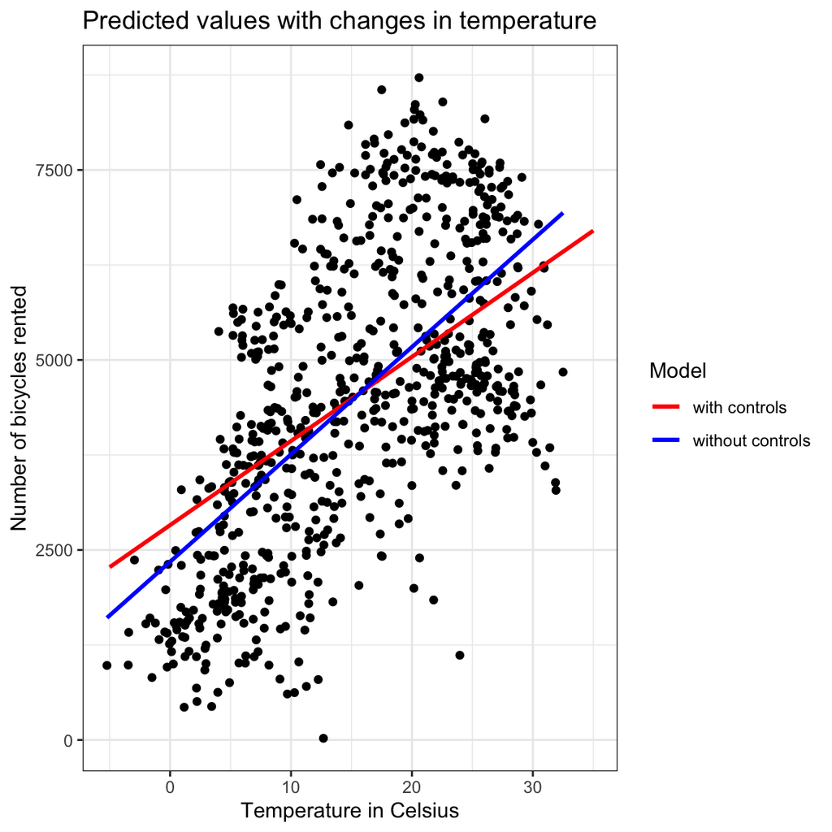

```r
# Fit the model at the mean
Modes <- function(x) {
  ux <- unique(x)
  tab <- tabulate(match(x, ux))
  ux[tab == max(tab)]
}

mean_dat <- apply(select_if(dat, is.numeric), 2, mean)
mean_dat <- data.frame(t(mean_dat))
mode_dat <- apply(select_if(dat, is.factor), 2, Modes)
mode_dat <- data.frame(t(mode_dat))
mean_obs <- cbind(mode_dat, mean_dat)
mean_obs2 <- mean_obs[rep(1, 40),]
mean_obs2$temp <- seq(-5, 35, length = 40)
mean_obs2$y_hat <- predict(mod, mean_obs2)

ggplot(dat, aes(y = y, x = temp)) +
  geom_point() +
  geom_line(data = mean_obs2, aes(x = temp, y = y_hat,
                                  color = "with controls"), size = 1) +
  stat_smooth(formula = 'y ~ x', method = lm, se = FALSE,
              aes(color = "without controls"),
              size = 1) +
  theme_bw() +
  labs(x = "Temperature in Celsius",
       y = "Number of bicycles rented",
       title = "Predicted values with changes in temperature") +
  scale_color_manual(name = "Model", values = c("red", "blue"))
```

#### Coef Plot

The information of the weight table (weight and variance estimates) can be visualized in a weight plot.

The following plot shows the results from the previous linear regression model.

To build our **Confidence Intervals**, we are going to follow the formula:
$$CI_j = \bar{x_j}\pm
z*\sigma_j$$
In where, $z$ corresponds to the confidence level value.

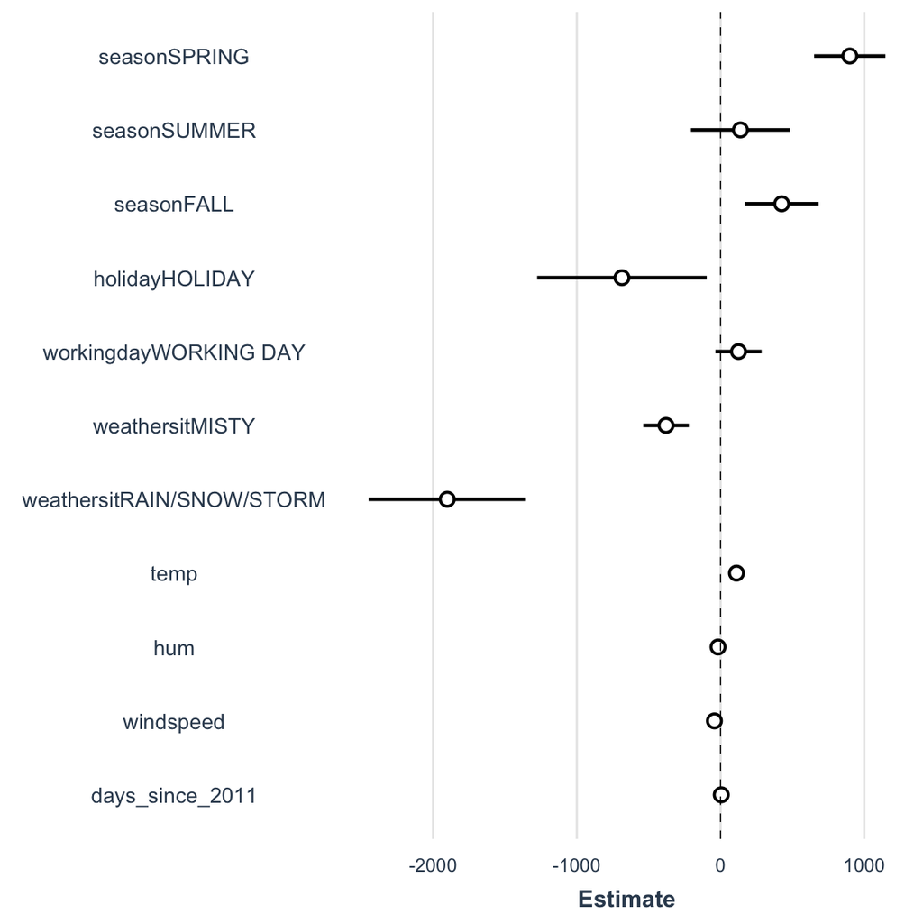

```r
# Using jtools function
plot_summs(mod, colors = "black", robust = TRUE)
```

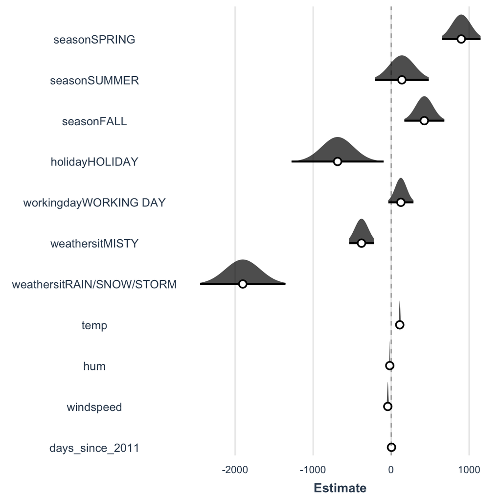

```r
plot_summs(mod, colors = "black", rescale.distributions = TRUE,
           plot.distributions = TRUE, robust = TRUE)
```

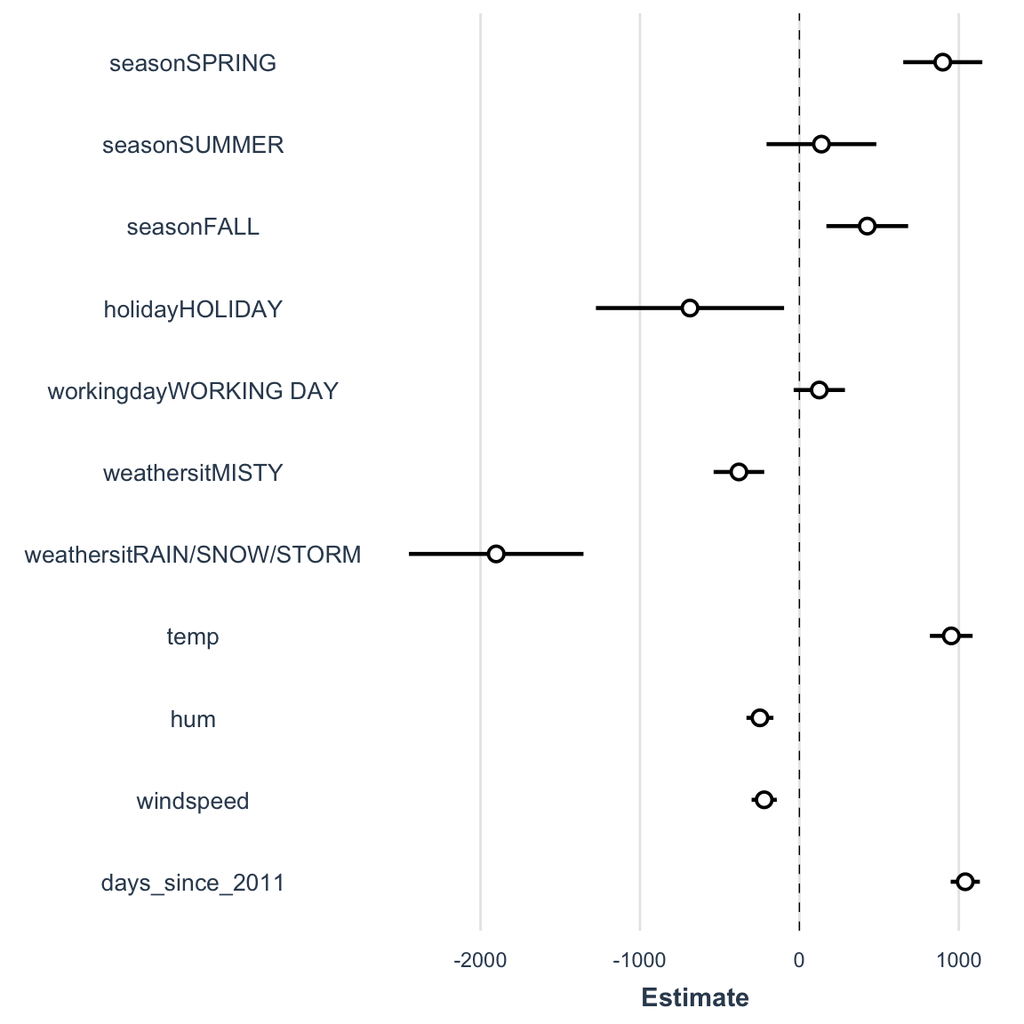

```r
plot_summs(mod, colors = "black", scale = TRUE, robust = TRUE)
```

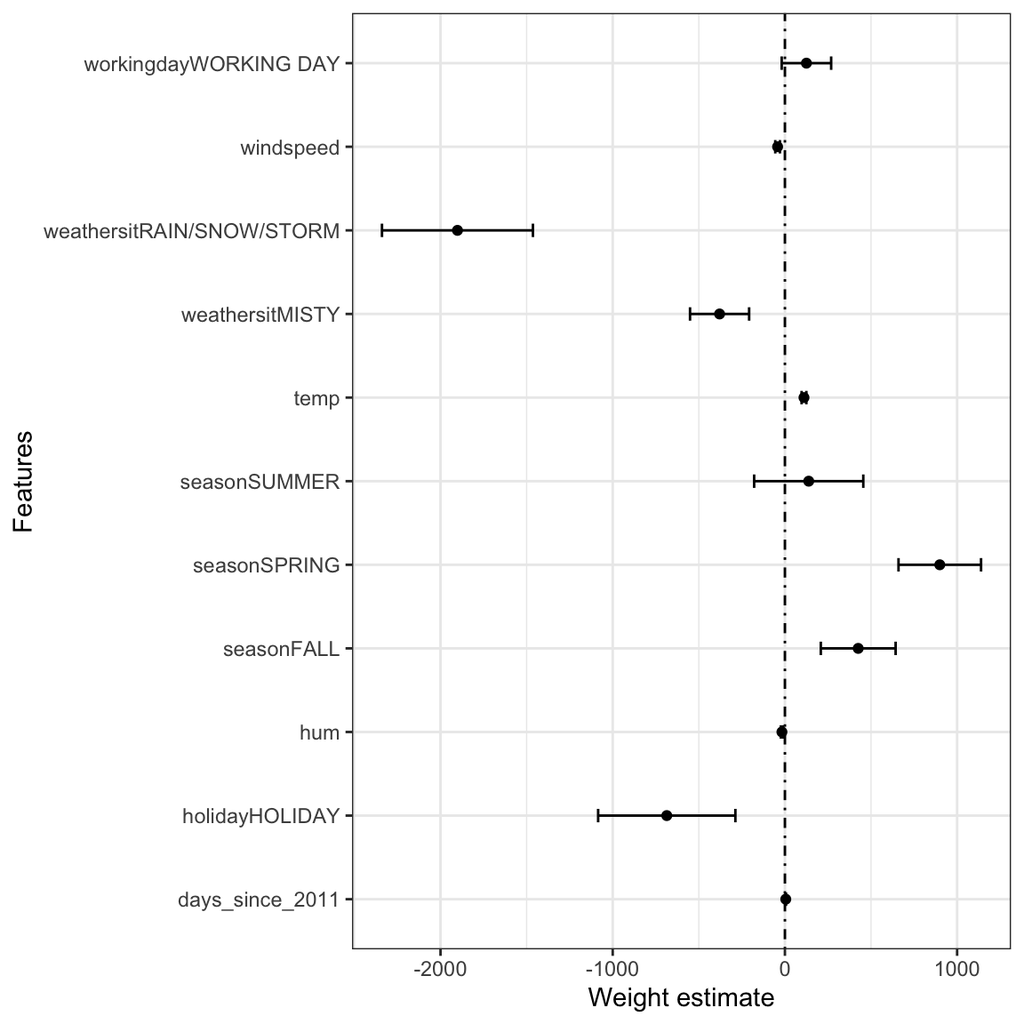

```r
# Building the plot by ourselves
weights = data.frame(
  Features = rownames(lm_summary),
  Estimate = lm_summary[,'Estimate'],
  std_error = lm_summary[,'Std. Error']
  )

# The function qnorm() find the boundary value that determines the area
# under the normal density curve before alpha/2.
alpha = 0.05 # 95% Confidence Interval
weights$lower = weights$Estimate - qnorm(alpha/2) * weights$std_error
weights$upper = weights$Estimate + qnorm(alpha/2) * weights$std_error
weights = weights[!(weights$Features == '(Intercept)'),]

ggplot(weights) +
  geom_vline(xintercept = 0, linetype = 4) +
  geom_point(aes(x = Estimate, y = Features)) +
  geom_segment(aes(y = Features, yend = Features, x = lower, xend = upper),
               arrow = arrow(angle = 90, ends = 'both',
                             length = unit(0.1, 'cm'))) +
  labs(x = 'Weight estimate') +
  theme_bw()
```

The weight plot shows that rainy/snowy/stormy weather has a strong negative effect on the predicted number of bikes.

The weight of the working day feature is close to zero and zero is included in the 95% interval, which means that the effect is not statistically significant.

Some confidence intervals are very short and the estimates are close to zero, yet the feature effects were statistically significant. Temperature is one such candidate.

The problem with the weight plot is that the features are measured on different scales.

While for the weather the estimated weight reflects the difference between good and rainy/stormy/snowy weather, for temperature it only reflects an increase of 1 degree Celsius.

You can make the estimated weights more comparable by scaling the features (zero mean and standard deviation of one) before fitting the linear model.

#### Effect Plot

The weights of the linear regression model can be more meaningfully analyzed when they are multiplied by the actual feature values.

The weights depend on the scale of the features and will be different if you have a feature that measures e.g. a person’s height and you switch from meter to centimeter.

The weight will change, but the actual effects in your data will not.

It is also important to know the distribution of your feature in the data, because if you have a very low variance, it means that almost all instances have similar contribution from this feature.

The effect plot can help you understand how much the combination of weight and feature contributes to the predictions in your data.

Start by calculating the effects, which is the weight per feature times the feature value of an instance:

$$\text{effect}_{j}^{(i)}=w_{j}x_{j}^{(i)}$$

The effects can be visualized with [boxplots](https://ggplot2.tidyverse.org/reference/geom_boxplot.html). The box in a boxplot contains the effect range for half of the data (25% to 75% effect quantiles). The vertical line in the box is the median effect, i.e. 50% of the instances have a lower and the other half a higher effect on the prediction. The dots are outliers, defined as points that are more than 1.5 * IQR (interquartile range, that is, the difference between the first and third quartiles) above the third quartile, or less than 1.5 * IQR below the first quartile. The two horizontal lines, called the lower and upper whiskers, connect the points below the first quartile and above the third quartile that are not outliers. If there are no outliers the whiskers will extend to the minimum and maximum values.

The categorical feature effects can be summarized in a single boxplot, compared to the weight plot, where each category has its own row.

```r
# Get weights for each observation (by ourselves)

# Create dummys
X <- model.matrix(y ~ ., data = dat)
# Column means
avx <- colMeans(X)
# X1 is centred by dropping column means
X1 <- sweep(X, 2L, avx)
# Get coefficients
beta <- mod$coef

head(t(beta*t(X1)))
```

```
##   (Intercept) seasonSPRING seasonSUMMER seasonFALL holidayHOLIDAY
## 1           0    -226.3674    -35.54651  -103.6352       19.71057
## 2           0    -226.3674    -35.54651  -103.6352       19.71057
## 3           0    -226.3674    -35.54651  -103.6352       19.71057
## 4           0    -226.3674    -35.54651  -103.6352       19.71057
## 5           0    -226.3674    -35.54651  -103.6352       19.71057
## 6           0    -226.3674    -35.54651  -103.6352       19.71057
##   workingdayWORKING DAY weathersitMISTY weathersitRAIN/SNOW/STORM       temp
## 1             -85.44524       -251.2023                    54.627  -786.8391
## 2             -85.44524       -251.2023                    54.627  -686.3572
## 3              39.47570        128.1962                    54.627 -1555.9099
## 4              39.47570        128.1962                    54.627 -1536.9905
## 5              39.47570        128.1962                    54.627 -1396.7238
## 6              39.47570        128.1962                    54.627 -1514.3664
##          hum  windspeed days_since_2011
## 1 -309.20804   85.56662       -1798.148
## 2 -118.50023 -165.35771       -1793.221
## 3  331.24602 -164.70258       -1788.295
## 4   65.09336   85.99388       -1783.368
## 5  331.79514   10.21497       -1778.442
## 6  190.51156  287.46367       -1773.515
```

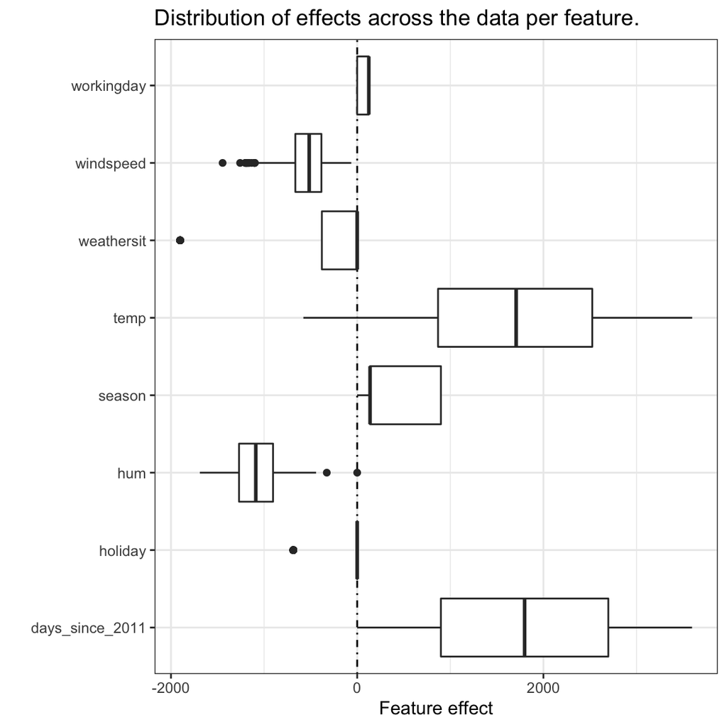

```r
# Get weights for each observation (using a function)
weights <- data.frame(predict(mod, type = 'terms'))

# Create reference dataset
get_reference_dataset = function(dat){
  df = lapply(dat, function(feature){
    if(class(feature) == 'factor'){
      factor(levels(feature)[1], levels = levels(feature))
    } else {
      0
    }
  })
  data.frame(df)
}
reference_dataset <- get_reference_dataset(dat)

reference_X = predict(mod, newdata = reference_dataset,
                      type = 'terms')

effect = data.frame(t(apply(weights, 1, function(x){ x -
    reference_X[1,names(weights)]})))
effect_long <- tidyr::gather(effect)

ggplot(effect_long) +
    geom_hline(yintercept = 0, linetype = 4) +
    geom_boxplot(aes(x = key, y = value, group = key)) +
    coord_flip() +
    scale_y_continuous('Feature effect') +
    scale_x_discrete('') +
  labs(title = "Distribution of effects across the data per feature.") +
    theme_bw()
```

The largest contributions to the expected number of rented bicycles comes from the temperature feature and the days feature, which captures the trend of bike rentals over time. The temperature has a broad range of how much it contributes to the prediction. The day trend feature goes from zero to large positive contributions, because the first day in the dataset (01.01.2011) has a very small trend effect and the estimated weight for this feature is positive (4.93). This means that the effect increases with each day and is highest for the last day in the dataset (31.12.2012). Note that for effects with a negative weight, the instances with a positive effect are those that have a negative feature value. For example, days with a high negative effect of windspeed are the ones with high wind speeds.

### **4.2 Explain Individual Predictions**

```r
i = 6
get_effects <- function(mod, dat) {

  X = data.frame(predict(mod, type = 'terms'))

  # Nicer colnames
  colnames(X) = gsub('^X\\.', '', colnames(X))
  colnames(X) = gsub('\\.', ' ', colnames(X))

  # predict with type='terms' centers the results, so we have to add the mean again
  reference_X = predict(mod, newdata=get_reference_dataset(dat), type='terms')
  X_star = data.frame(t(apply(X, 1, function(x){ x - reference_X[1,names(X)]})))
  X_star
}

effects = get_effects(mod, dat)
predictions = predict(mod)

effects_i = tidyr::gather(effects[i, ])
predictions_mean = mean(predictions)

# For proper indexing, names have to be removed
names(predictions) = NULL
pred_i = predictions[i]
```

How much has each feature of an instance contributed to the prediction? This can be answered by computing the effects for this instance. An interpretation of instance-specific effects only makes sense in comparison to the distribution of the effect for each feature. We want to explain the prediction of the linear model for the 6-th instance from the bicycle dataset. The instance has the following feature values.

```r
df = data.frame(feature = colnames(bike), value = t(bike[i,]))
colnames(df) = c("feature", "value")
kable(df, col.names = c("Feature", "Value"), row.names = FALSE, booktabs = TRUE, caption = sprintf("Feature values for instance %i", i)) %>% kable_styling(position = "center")
```

Feature values for instance 6

| Feature | Value |
| --- | --- |
| season | WINTER |
| yr | 2011 |
| mnth | JAN |
| holiday | NO HOLIDAY |
| weekday | THU |
| workingday | WORKING DAY |
| weathersit | GOOD |
| temp | 1.604356 |
| hum | 51.8261 |
| windspeed | 6.000868 |
| cnt | 1606 |
| days_since_2011 | 5 |

To obtain the feature effects of this instance, we have to multiply its feature values by the corresponding weights from the linear regression model. For the value “WORKING DAY” of feature “workingday”, the effect is, 124.9. For a temperature of 1.6 degrees Celsius, the effect is 177.6. We add these individual effects as crosses to the effect plot, which shows us the distribution of the effects in the data. This allows us to compare the individual effects with the distribution of effects in the data.

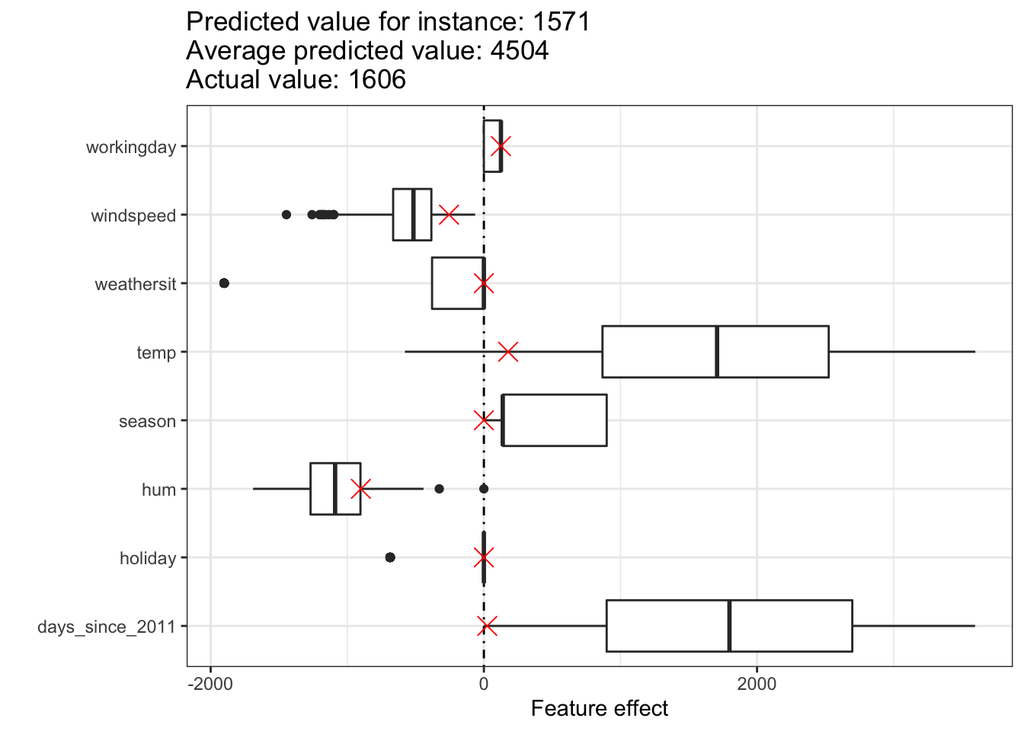

The effect plot for one instance shows the effect distribution and highlights the effects of the instance of interest.

```r
ggplot(effect_long) +
  geom_hline(yintercept = 0, linetype = 4) +
  geom_boxplot(aes(x = key, y = value, group = key)) +
  coord_flip() +
  scale_y_continuous('Feature effect') +
  scale_x_discrete('') +
  theme_bw() +
  geom_point(data= effects_i, aes(x = key, y = value), color = 'red',
             shape = 4, size=4) +
  ggtitle(sprintf('Predicted value for instance: %.0f\nAverage predicted value: %.0f\nActual value: %.0f', pred_i, predictions_mean, y[i]))
```

If we average the predictions for the training data instances, we get an average of 4504. In comparison, the prediction of the 6-th instance is small, since only 1571 bicycle rents are predicted. The effect plot reveals the reason why. The boxplots show the distributions of the effects for all instances of the dataset, the crosses show the effects for the 6-th instance. The 6-th instance has a low temperature effect because on this day the temperature was 2 degrees, which is low compared to most other days (and remember that the weight of the temperature feature is positive). Also, the effect of the trend feature “days_since_2011” is small compared to the other data instances because this instance is from early 2011 (5 days) and the trend feature also has a positive weight.

### **4.3 Encoding of Categorical Features**

There are several ways to encode a categorical feature, and the choice influences the interpretation of the weights.

The standard in linear regression models is treatment coding, which is sufficient in most cases. Using different encodings boils down to creating different (design) matrices from a single column with the categorical feature. This section presents three different encodings, but there are many more. The example used has six instances and a categorical feature with three categories. For the first two instances, the feature takes category A; for instances three and four, category B; and for the last two instances, category C.

**Treatment coding**

In treatment coding, the weight per category is the estimated difference in the prediction between the corresponding category and the reference category. The intercept of the linear model is the mean of the reference category (when all other features remain the same). The first column of the design matrix is the intercept, which is always 1. Column two indicates whether instance i is in category B, column three indicates whether it is in category C. There is no need for a column for category A, because then the linear equation would be overspecified and no unique solution for the weights can be found. It is sufficient to know that an instance is neither in category B or C.

Feature matrix:
$$\begin{pmatrix}1&0&0\\1&0&0\\1&1&0\\1&1&0\\1&0&1\\1&0&1\\\end{pmatrix}$$

**Effect coding**

The weight per category is the estimated y-difference from the corresponding category to the overall mean (given all other features are zero or the reference category). The first column is used to estimate the intercept. The weight $\beta_{0}$ associated with the intercept represents the overall mean and $\beta_{1}$, the weight for column two, is the difference between the overall mean and category B. The total effect of category B is $\beta_{0}+\beta_{1}$. The interpretation for category C is equivalent. For the reference category A, $-(\beta_{1}+\beta_{2})$ is the difference to the overall mean and $\beta_{0}-(\beta_{1}+\beta_{2})$ the overall effect.

Feature matrix:
$$\begin{pmatrix}1&-1&-1\\1&-1&-1\\1&1&0\\1&1&0\\1&0&1\\1&0&1\\\end{pmatrix}$$

**Dummy coding**

The $\beta$ per category is the estimated mean value of y for each category (given all other feature values are zero or the reference category). Note that the intercept has been omitted here so that a unique solution can be found for the linear model weights. Another way to mitigate this multicollinearity problem is to leave out one of the categories.

Feature matrix:
$$\begin{pmatrix}1&0&0\\1&0&0\\0&1&0\\0&1&0\\0&0&1\\0&0&1\\\end{pmatrix}$$

If you want to dive a little deeper into the different encodings of categorical features, checkout [this overview webpage](http://stats.idre.ucla.edu/r/library/r-library-contrast-coding-systems-for-categorical-variables/) and [this blog post](http://heidiseibold.github.io/page7/).